# Section 1: Create Notebook

# Section 2.3: Create *calculateTrajectories* Function

```python
def calculateTrajectories(masses,positions,velocities,time=1.0,tstep=0.001): #default time of 1 second at 0.001 seconds timestep
    '''
    A function to calculate trajectories of N particles in 3-D space under the influence of gravity.

    Parameters
    -------
    masses : np.ndarray
        1-D array containing masses for all particles, in kg
        It has length N, where N is the number of particles.
    positions : np.ndarray
        2-D array containing (x, y, z) positions for all particles.
        Shape is (N, 3) where N is the number of particles.
    velocities : np.ndarray
        2-D array containing (x, y, z) velocities for all particles.
        Shape is (N, 3) where N is the number of particles.
    time : float
        The total time of the trajectory, in seconds.
    tstep : float
        The time step value used for numerical integration of the
        trajectories.  Smaller time steps produce greater accuracy.

    Returns
    --------
    times : nd.ndarray
        1-D array containing the time values for all steps of the trajectory.
        It has length T, where T = time / tstep.
    position_history : nd.ndarray
        3-D array containing the x,y,z positions of all particles at each time step.
        Shape is (N, 3, T) where N is number of particles and T is time steps.
    velocity_history : nd.ndarray
        3-D array containing the x,y,z velocities of all particles at each time step.
        Shape is (N, 3, T) where N is number of particles and T is time steps.

    Other Functions Called
    -------------------
    forces.magnitude
    forces.unitDirectionVector
    forces.forceVector
    forces.calculateForceVectors
    leapfrog.updateParticles
    '''
    import leapfrog as lf

    N = np.shape(positions)[0]                             #get a number of particles
    position_history = np.reshape(positions,(N,3,1))       #reshape arrays to 3D
    velocity_history = np.reshape(velocities,(N,3,1))
    times = np.array([0.0])                                #initialize times output array
    while times[-1] < time:
        newposition, newvelocity = lf.updateParticles(masses, position_history[:,:,-1], velocity_history[:,:,-1], tstep)
        times = np.append(times, [times[-1] + tstep])      #update times
        position_history = np.append(position_history, np.reshape(newposition,(N,3,1)),axis=2) #add new positions on end
        velocity_history = np.append(velocity_history, np.reshape(newvelocity,(N,3,1)),axis=2) #add new velocities on end
    return times, position_history, velocity_history
```

# Section 3.4: Earth-Sun System

```python
AU = 1.496e11                                                       #1 AU in meters
masses_ES = np.array([1.989e30,5.972e24])
positions_ES = np.array([[-3e-6*AU,0,0],[0.999997*AU,0,0]])    #positions of Earth and Sun in meters
velocity_ES = np.array([[0,-8.94e-2,0],[0,2.98e4,0]])              #velocities of Earth and Sun in m/s
```

```python
times_ES, position_history_ES, velocity_history_ES = calculateTrajectories(masses_ES,
                                                                           positions_ES,velocity_ES,time=8.64e7,tstep=8.64e3)
#calculate trajectories using the above initial data, with total time 8.64e7 seconds(1000 days),
                                                                            #time steps of 8640 seconds(0.1 days)
```

# Section 3.5: Plot The Earth-Sun System

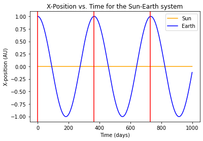

```python
times_ES_days = times_ES / 86400                            #convert times to days
position_history_ES_AU = position_history_ES / AU           #convert position to AU
plt.plot(times_ES_days,position_history_ES_AU[0,0,:],color = 'orange', label = 'Sun')  #plot x-position vs time
plt.plot(times_ES_days,position_history_ES_AU[1,0,:],color = 'blue', label = 'Earth')
plt.xlabel('Time (days)')
plt.ylabel('X-position (AU)')
plt.legend()
plt.title('X-Position vs. Time for the Sun-Earth system')
plt.axvline(0,color = 'red')                                #plot lines 365 days apart to see that they roughly correspond
plt.axvline(365,color = 'red')                              #to peaks in the graph
plt.axvline(730,color = 'red');
```

We can see here that the x-position of the Earth follows a sinusoidal pattern with a period of almost exactly 365 days. The Sun presumably does oscillate slightly, but these oscillations are too small to see on this plot. All of these results are as expected.

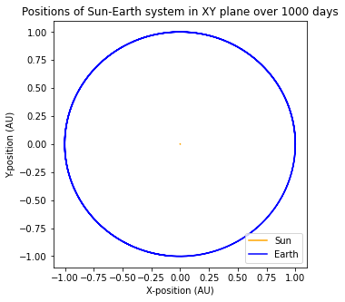

```python
plt.matplotlib.rcParams['figure.figsize'] = (5, 5)         #create a square figure to show the orbit as a circle
plt.plot(position_history_ES_AU[0,0,:],position_history_ES_AU[0,1,:], color = 'orange', label = 'Sun')  #plot xy positions
plt.plot(position_history_ES_AU[1,0,:],position_history_ES_AU[1,1,:], color = 'blue', label = 'Earth')
plt.xlim(-1.1,1.1)                  #set x and y limits the same, slightly larger than expected values
plt.ylim(-1.1,1.1)
plt.xlabel('X-position (AU)')
plt.ylabel('Y-position (AU)')
plt.legend()
plt.title('Positions of Sun-Earth system in XY plane over 1000 days');
```

Here we see that the Earth traces out a circular orbit in the XY plane. Once again, any oscillations the Sun undergoes are too small to see at this scale.

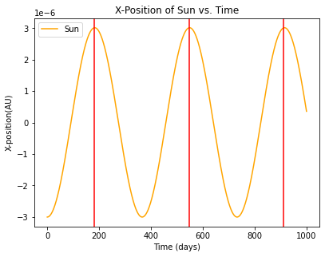

```python
plt.matplotlib.rcParams['figure.figsize'] = (6.4,4.8)             #return figure size to default
plt.plot(times_ES_days,position_history_ES_AU[0,0,:], color = 'orange', label = 'Sun') #plot x-position vs time in days
plt.xlabel('Time (days)')
plt.ylabel('X-position(AU)')
plt.legend()
plt.title('X-Position of Sun vs. Time')
plt.axvline(182.5,color = 'red')                  #plot vertical lines which should roughly correspond to peaks in the graph
plt.axvline(547.5,color = 'red')
plt.axvline(912.5,color = 'red');
```

Here we can confirm that the Sun does indeed oscillate as expected. The period is approximately 365 days, just as the Earth was in the plot above, however the Sun is at the opposite phase. The oscillations take place between -3e-6 AU and 3e-6 AU. The total distance traveled by the Sun's center of mass is thus 6e-6 AU, which is 8.976e5 meters. This distance is traveled over 182.5 days, or 1.5768e7 seconds. Thus the Sun's average radial velocity over half of its orbit is 0.057 m/s. To detect an Earthlike planet orbiting a Sunlike star at 1 AU distance using the wobble method, we would need to measure that star's radial velocity to a precision of at least 0.01 m/s.

# Section 3.6: Earth-Sun System with Velocity Halved

```python
masses_ES2 = np.array([1.989e30,5.972e24])                      #masses of Sun and Earth in kg
positions_ES2 = np.array([[-3e-6*AU,0,0],[0.999997*AU,0,0]])    #positions of Sun and Earth in meters
velocity_ES2 = (np.array([[0,-8.94e-2,0],[0,2.98e4,0]]))/2.0              #velocities of Earth and Sun in m/s, halved
times_ES2, position_history_ES2, velocity_history_ES2 = calculateTrajectories(masses_ES2,
                                                                           positions_ES2,velocity_ES2,time=8.64e7,tstep=8.64e3)
#calculate trajectory for velocity halved
```

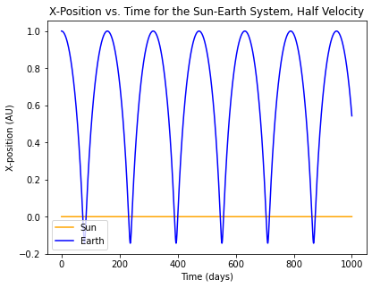

```python
times_ES2_days = times_ES2 / 86400                            #convert times to days
position_history_ES2_AU = position_history_ES2 / AU           #convert position to AU
plt.plot(times_ES2_days,position_history_ES2_AU[0,0,:],color = 'orange', label = 'Sun')  #plot x-position vs time
plt.plot(times_ES2_days,position_history_ES2_AU[1,0,:],color = 'blue', label = 'Earth')
plt.xlabel('Time (days)')
plt.ylabel('X-position (AU)')
plt.legend()
plt.title('X-Position vs. Time for the Sun-Earth System, Half Velocity');
```

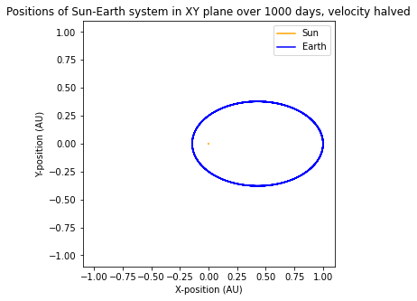

```python
plt.matplotlib.rcParams['figure.figsize'] = (5, 5)         #create a square figure
plt.plot(position_history_ES2_AU[0,0,:],position_history_ES2_AU[0,1,:], color = 'orange', label = 'Sun')  #plot xy positions
plt.plot(position_history_ES2_AU[1,0,:],position_history_ES2_AU[1,1,:], color = 'blue', label = 'Earth')
plt.xlim(-1.1,1.1)                  #set x and y limits the same, slightly larger than expected values
plt.ylim(-1.1,1.1)
plt.xlabel('X-position (AU)')
plt.ylabel('Y-position (AU)')
plt.legend()
plt.title('Positions of Sun-Earth system in XY plane over 1000 days, velocity halved');
```

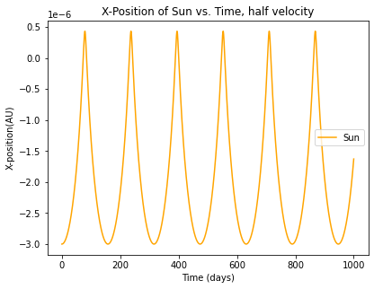

```python
plt.matplotlib.rcParams['figure.figsize'] = (6.4,4.8)             #return figure size to default
plt.plot(times_ES2_days,position_history_ES2_AU[0,0,:], color = 'orange', label = 'Sun') #plot x-position vs time in days
plt.xlabel('Time (days)')
plt.ylabel('X-position(AU)')
plt.legend()
plt.title('X-Position of Sun vs. Time, half velocity');
```

We can see from the above figures that halving the initial velocity for the Sun-Earth system produces an elliptical orbit with an apoapse at one AU. This was not my initial expectation, but on reflection it should have been. An orbiting object must exhibit periodic motion; it must return to each relative position over the course of its orbit. If it begins an orbit at a particular postion, with a particular velocity, it must return to that position and velocity.  
In a circular orbit, an object has enough energy to reach the far side of its orbit with the same velocity as the near side. If you reduce the velocity without changing the position, it still has to return to that position, but it now lacks the energy necessary to reach the other side of the orbit at the same distance from the primary. Its orbit therefore becomes elliptical, with a nearer position but a higher velocity at periapse.

# Section 4.7: Read Data For Kepler 16ABb Circumbinary System

```python
!head 'kepler16.txt'                     #evaluate text data file
```

```
# mass (kg)   x (m)       y (m)       z (m)       vx (m/s)    vy (m/s)    vz (m/s)
+1.3718e+30 +7.6349e+09 -9.6587e+05 +1.8447e+09 -1.0502e+03 -6.8224e+00 +1.3030e+04
+4.0287e+29 -2.5998e+10 +3.2889e+06 -6.2813e+09 +3.5760e+03 +2.3231e+01 -4.4368e+04
+6.3250e+26 +3.7761e+10 -4.0923e+07 +8.1934e+10 -3.6298e+04 -1.0812e+01 +1.7020e+04
```

```python
import pandas as pd
kepler16 = pd.read_csv('kepler16.txt', comment='#',sep='\s+',names=['mass','x','y','z','vx','vy','vz'])
kepler16                                                #read in text data using pandas and display
```

|  | mass | x | y | z | vx | vy | vz |
| --- | --- | --- | --- | --- | --- | --- | --- |
| 0 | 1.371800e+30 | 7.634900e+09 | -965870.0 | 1.844700e+09 | -1050.2 | -6.8224 | 13030.0 |
| 1 | 4.028700e+29 | -2.599800e+10 | 3288900.0 | -6.281300e+09 | 3576.0 | 23.2310 | -44368.0 |
| 2 | 6.325000e+26 | 3.776100e+10 | -40923000.0 | 8.193400e+10 | -36298.0 | -10.8120 | 17020.0 |

```python
masses_K16 = kepler16['mass'].values                           #put masses into 1D array
#put positions and velocities into 2D arrays.  Transpose to get proper arrangement of values for calculateTrajectories.
positions_K16 = np.array([kepler16['x'].values,kepler16['y'].values,kepler16['z'].values])
positions_K16 = np.transpose(positions_K16)
velocities_K16 = np.array([kepler16['vx'].values,kepler16['vy'].values,kepler16['vz'].values])
velocities_K16 = np.transpose(velocities_K16)
```

```python
N = np.shape(positions_K16)[0]                                   #get a number of particles
positions_K16_AU = positions_K16 / AU                            #convert from meters to AU
                                                                 #normalize masses
normal_masses_K16 = (((masses_K16 - np.min(masses_K16))/(np.max(masses_K16)-np.min(masses_K16))*180)+20)
forces_K16 = forces.calculateForceVectors(masses_K16, positions_K16)  #calculate force vectors for quiver
```

# Section 4.8: Plot Initial Positions of Kepler-16ABb

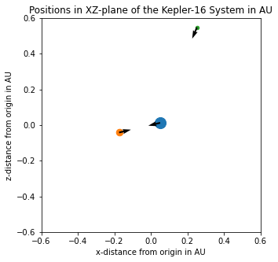

```python
plt.matplotlib.rcParams['figure.figsize'] = (5, 5)         #create square plot
for i in range(N):
    plt.scatter((positions_K16_AU[i][0]),(positions_K16_AU[i][2]), s=normal_masses_K16[i])   #plot objects
    plt.quiver((positions_K16_AU[i][0]),(positions_K16_AU[i][2]),(forces_K16[i][0]/AU),(forces_K16[i][2]/AU)) #plot vectors

plt.xlabel('x-distance from origin in AU')
plt.ylabel('z-distance from origin in AU')
plt.title('Positions in XZ-plane of the Kepler-16 System in AU')
plt.xlim(-0.6,0.6)
plt.ylim(-0.6,0.6);
```

# Section 4.9: Calculate Trajectories For Kepler-16ABb

```python
times_K16, position_history_K16, velocity_history_K16 = calculateTrajectories(masses_K16,
                                                                              positions_K16,velocities_K16,
                                                                              time=4.32e7,tstep=4.32e4)
#calculate trajectories using the above initial data, with total time 500 days, time steps of 0.5 days
```

```python
N = np.shape(positions_K16)[0]                           #calculate forces at all time steps, to use quiver in animation
forces_history_K16 = np.reshape(forces.calculateForceVectors(masses_K16, positions_K16),(N,3,1))
for i in range(len(times_K16)-1):
    forces_K16 = forces.calculateForceVectors(masses_K16, position_history_K16[:,:,(i+1)])
    forces_history_K16 = np.append(forces_history_K16,np.reshape(forces_K16,(N,3,1)),axis=2)
print(np.shape(forces_history_K16))
```

```
(3, 3, 1001)
```

# Section 4.10: Animate the Kepler-16ABb System

```
saving movie frame 0
saving movie frame 50
saving movie frame 100
saving movie frame 150
saving movie frame 200
saving movie frame 250
saving movie frame 300
saving movie frame 350
saving movie frame 400
saving movie frame 450
saving movie frame 500
saving movie frame 550
saving movie frame 600
saving movie frame 650
saving movie frame 700
saving movie frame 750
saving movie frame 800
saving movie frame 850
saving movie frame 900
saving movie frame 950
saving movie frame 1000
```

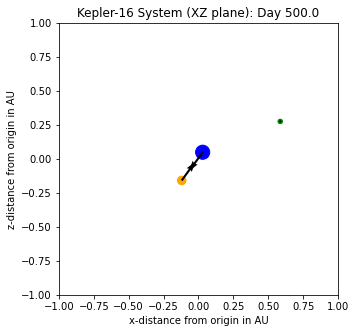

```python
import matplotlib.animation as ani           #import animation tool and initialize animation object
FFMpegWriter = ani.writers['ffmpeg']
writer = FFMpegWriter(fps=20)

fig = plt.figure(figsize=(5,5))              #set up figure
#fig.patch.set_alpha(1.0)
#ax = plt.axes(projection='3d')

with writer.saving(fig, "Kepler16_2D.mp4", 200):
    for i in range(0,len(times_K16),2):                 #time step was 0.5 days, so get one frame per day
        plt.cla()
        #ax.view_init(10, 30)

        plt.scatter((position_history_K16[:,0,i]/AU),(position_history_K16[:,2,i]/AU), s=normal_masses_K16,
                    c=['blue','orange','green'])
        plt.quiver((position_history_K16[:,0,i]/AU),(position_history_K16[:,2,i]/AU),
                   (forces_history_K16[:,0,i]/AU),(forces_history_K16[:,2,i]/AU))

        plt.xlabel('x-distance from origin in AU')
        plt.ylabel('z-distance from origin in AU')
        plt.title(f'Kepler-16 System (XZ plane): Day {times_K16[i]/86400}')
        plt.xlim(-1,1)
        plt.ylim(-1,1);

        if i % 50 == 0:
            print(f"saving movie frame {i}")
        writer.grab_frame()
```

```python
from IPython.display import Video               #watch the movie!
Video("Kepler16_2D.mp4", embed=True)
```

[video not shown]

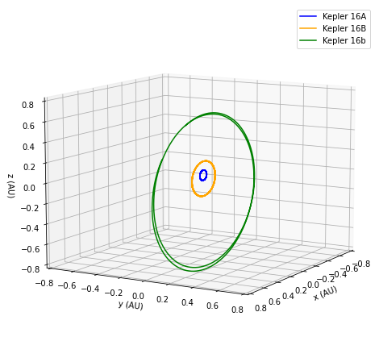

```python
from mpl_toolkits import mplot3d                            #make 3D plot of the system for practice
plt.matplotlib.rcParams['figure.figsize'] = (8, 8)
ax = plt.axes(projection='3d')
ax.view_init(10, 30)
ax.set_xlabel('x (AU)'); ax.set_ylabel('y (AU)'); ax.set_zlabel('z (AU)')
ax.set_xlim(-0.8,0.8); ax.set_ylim(-0.8,0.8); ax.set_zlim(-0.8,0.8)

ax.plot(position_history_K16[0,0,:]/AU, position_history_K16[0,1,:]/AU,
        position_history_K16[0,2,:]/AU, color='blue', label="Kepler 16A")
ax.plot(position_history_K16[1,0,:]/AU, position_history_K16[1,1,:]/AU,
        position_history_K16[1,2,:]/AU, color='orange', label="Kepler 16B")
ax.plot(position_history_K16[2,0,:]/AU, position_history_K16[2,1,:]/AU,
        position_history_K16[2,2,:]/AU, color='green', label="Kepler 16b")
ax.legend();
```

```
saving movie frame 0
saving movie frame 50
saving movie frame 100
saving movie frame 150
saving movie frame 200
saving movie frame 250
saving movie frame 300
saving movie frame 350
saving movie frame 400
saving movie frame 450
saving movie frame 500
saving movie frame 550
saving movie frame 600
saving movie frame 650
saving movie frame 700
saving movie frame 750
saving movie frame 800
saving movie frame 850
saving movie frame 900
saving movie frame 950
saving movie frame 1000
```

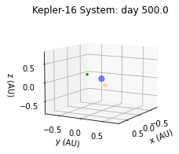

```python
#make 3D animation of Kepler-16 to practice

import matplotlib.animation as ani           #import animation tool and initialize animation object
FFMpegWriter = ani.writers['ffmpeg']
writer = FFMpegWriter(fps=20)

fig = plt.figure(figsize=(4,3))              #set up 3D figure
fig.patch.set_alpha(1.0)
ax = plt.axes(projection='3d')

with writer.saving(fig, "Kepler16_3D.mp4", 200):
    for i in range(0,len(times_K16),2):                 #time step was 0.5 days, so get one frame per day
        plt.cla()
        ax.view_init(10, 30)

        ax.scatter(position_history_K16[:,0,i]/AU,position_history_K16[:,1,i]/AU,
                   position_history_K16[:,2,i]/AU,s=normal_masses_K16/4,color=['blue','orange','green'])
        ax.set_xlim(-0.8,0.8); ax.set_ylim(-0.8,0.8); ax.set_zlim(-0.8,0.8)
        ax.set_xlabel('x (AU)'); ax.set_ylabel('y (AU)'); ax.set_zlabel('z (AU)')
        ax.set_title(f'Kepler-16 System: day {times_K16[i]/86400}')

        if i % 50 == 0:
            print(f"saving movie frame {i}")
        writer.grab_frame()
```

```python
from IPython.display import Video               #watch the movie!
Video("Kepler16_3D.mp4", embed=True)
```

[video not shown]

# Section 5.11: Choose Your Own Adventure

```python
!head 'planetesimalDisk.txt'             #evaluate text file
```

```
# mass (kg)   x (m)       y (m)       z (m)       vx (m/s)    vy (m/s)    vz (m/s)
+1.9890e+30 -0.0000e+00 +0.0000e+00 -0.0000e+00 -0.0000e+00 -0.0000e+00 +0.0000e+00
+1.9890e+20 -9.8471e+10 +1.9358e+10 -0.0000e+00 -7.0155e+03 -3.5687e+04 +1.4760e+03
+1.9890e+20 +9.2346e+09 +1.0289e+11 -0.0000e+00 -3.5704e+04 +3.2046e+03 -1.1354e+02
+1.9890e+20 +6.1308e+10 -9.1514e+10 +0.0000e+00 +2.8841e+04 +1.9321e+04 +1.1089e+03
+1.9890e+20 -5.5122e+10 -1.1849e+11 +0.0000e+00 +2.8897e+04 -1.3443e+04 -3.2428e+02
+1.9890e+20 -9.7365e+09 -4.8895e+10 +0.0000e+00 +5.0608e+04 -1.0078e+04 +5.7392e+02
+1.9890e+20 +6.9612e+10 +9.7390e+10 -0.0000e+00 -2.7091e+04 +1.9364e+04 -3.5236e+02
+1.9890e+20 -1.2054e+10 +7.5797e+10 -0.0000e+00 -4.1073e+04 -6.5318e+03 +1.3317e+03
+1.9890e+20 -4.4645e+10 -9.2515e+10 -0.0000e+00 +3.2376e+04 -1.5624e+04 -2.0415e+03
```

```python
pDisk = pd.read_csv('planetesimalDisk.txt', comment='#',sep='\s+',names=['mass','x','y','z','vx','vy','vz'])
pDisk                                    #read in text file and display
```

|  | mass | x | y | z | vx | vy | vz |
| --- | --- | --- | --- | --- | --- | --- | --- |
| 0 | 1.989000e+30 | -0.000000e+00 | 0.000000e+00 | -0.0 | -0.0 | -0.0 | 0.00 |
| 1 | 1.989000e+20 | -9.847100e+10 | 1.935800e+10 | -0.0 | -7015.5 | -35687.0 | 1476.00 |
| 2 | 1.989000e+20 | 9.234600e+09 | 1.028900e+11 | -0.0 | -35704.0 | 3204.6 | -113.54 |
| 3 | 1.989000e+20 | 6.130800e+10 | -9.151400e+10 | 0.0 | 28841.0 | 19321.0 | 1108.90 |
| 4 | 1.989000e+20 | -5.512200e+10 | -1.184900e+11 | 0.0 | 28897.0 | -13443.0 | -324.28 |
| 5 | 1.989000e+20 | -9.736500e+09 | -4.889500e+10 | 0.0 | 50608.0 | -10078.0 | 573.92 |
| 6 | 1.989000e+20 | 6.961200e+10 | 9.739000e+10 | -0.0 | -27091.0 | 19364.0 | -352.36 |
| 7 | 1.989000e+20 | -1.205400e+10 | 7.579700e+10 | -0.0 | -41073.0 | -6531.8 | 1331.70 |
| 8 | 1.989000e+20 | -4.464500e+10 | -9.251500e+10 | -0.0 | 32376.0 | -15624.0 | -2041.50 |
| 9 | 1.989000e+20 | 7.702800e+10 | -1.079800e+10 | -0.0 | 5734.9 | 40912.0 | 958.19 |
| 10 | 1.989000e+20 | 1.793500e+10 | -6.717700e+10 | 0.0 | 42216.0 | 11271.0 | -1368.60 |
| 11 | 1.989000e+20 | -1.005800e+10 | -5.073900e+10 | -0.0 | 49692.0 | -9850.3 | -831.45 |
| 12 | 1.989000e+20 | -2.630400e+10 | 4.171000e+10 | -0.0 | -43886.0 | -27677.0 | -1672.80 |
| 13 | 1.989000e+20 | 3.747200e+10 | 3.242700e+10 | 0.0 | -33868.0 | 39138.0 | 1038.90 |
| 14 | 1.989000e+20 | 1.218300e+11 | 4.100400e+10 | 0.0 | -10250.0 | 30456.0 | -1465.80 |
| 15 | 1.989000e+20 | -6.015300e+10 | 9.326600e+10 | -0.0 | -29064.0 | -18745.0 | 1330.50 |
| 16 | 1.989000e+20 | 1.067900e+11 | -6.943700e+10 | 0.0 | 17598.0 | 27064.0 | -618.54 |
| 17 | 1.989000e+20 | 4.571300e+10 | 2.176200e+10 | 0.0 | -22010.0 | 46234.0 | -214.71 |
| 18 | 1.989000e+20 | -3.467200e+10 | 1.049100e+11 | 0.0 | -32911.0 | -10877.0 | 575.36 |
| 19 | 1.989000e+20 | 6.465000e+10 | -3.675700e+10 | 0.0 | 20882.0 | 36728.0 | -250.50 |
| 20 | 1.989000e+20 | -7.829200e+10 | -1.751700e+10 | -0.0 | 8881.5 | -39696.0 | -172.89 |
| 21 | 1.989000e+20 | 5.475300e+09 | 1.396700e+11 | 0.0 | -30794.0 | 1207.2 | 35.94 |
| 22 | 1.989000e+20 | -8.017100e+10 | -1.321200e+10 | -0.0 | 6572.3 | -39882.0 | -582.21 |
| 23 | 1.989000e+20 | 5.215400e+10 | 5.986200e+10 | 0.0 | -30830.0 | 26861.0 | 650.24 |
| 24 | 1.989000e+20 | 9.504900e+10 | -2.205000e+10 | 0.0 | 8335.5 | 35931.0 | 172.42 |
| 25 | 1.989000e+20 | -6.256400e+10 | -1.626300e+10 | -0.0 | 11401.0 | -43858.0 | 449.07 |
| 26 | 1.989000e+20 | 6.773000e+10 | -2.717400e+10 | -0.0 | 15881.0 | 39583.0 | 820.04 |
| 27 | 1.989000e+20 | -3.409900e+10 | 1.235100e+11 | 0.0 | -31027.0 | -8566.2 | -107.24 |
| 28 | 1.989000e+20 | 1.040100e+11 | -6.587200e+10 | -0.0 | 17569.0 | 27741.0 | 513.48 |
| 29 | 1.989000e+20 | 8.005700e+10 | -6.783600e+10 | 0.0 | 22994.0 | 27136.0 | -1049.90 |

```python
masses_pDisk = pDisk['mass'].values                           #move data into properly sized arrays
positions_pDisk = np.array([pDisk['x'].values,pDisk['y'].values,pDisk['z'].values])
positions_pDisk = np.transpose(positions_pDisk)
velocities_pDisk = np.array([pDisk['vx'].values,pDisk['vy'].values,pDisk['vz'].values])
velocities_pDisk = np.transpose(velocities_pDisk)
                                                               #normalize masses
normal_masses_pDisk = (((masses_pDisk - np.min(masses_pDisk))/(np.max(masses_pDisk)-np.min(masses_pDisk))*10)+1)
```

```python
#calculate trajectories for 1000 days, time step 0.1 days

times_pDisk, position_history_pDisk, velocity_history_pDisk = calculateTrajectories(masses_pDisk,
                                                                              positions_pDisk,velocities_pDisk,
                                                                              time=8.64e7,tstep=8.64e3)
```

```python
colorarray = np.linspace(0.0,1.0,10)
colorlist = [np.array([1,0,0])]                        #create a list of color values to use for plotting
for k in range(9):
    colorlist.append(np.array([1,colorarray[k+1],0]))
for j in range(10):
    colorlist.append(np.array([0,1,colorarray[j]]))
for i in range(10):
    colorlist.append(np.array([0,colorarray[9-i],1]))
```

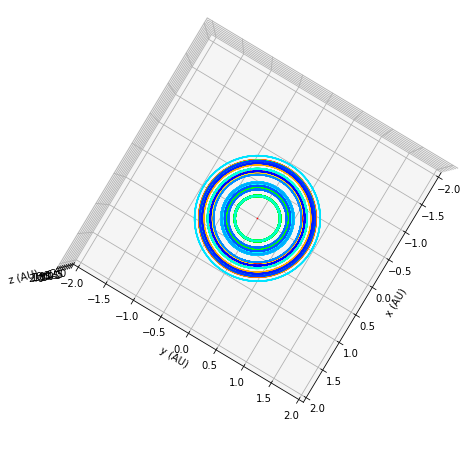

```python
r = 2                                            #set variable to control axis limits
plt.matplotlib.rcParams['figure.figsize'] = (8, 8)                  #make 3D plot to evaluate dataset
ax = plt.axes(projection='3d')                                      #find limits for scaling axes
ax.view_init(90, 30)
ax.set_xlabel('x (AU)'); ax.set_ylabel('y (AU)'); ax.set_zlabel('z (AU)')
ax.set_xlim(-r,r); ax.set_ylim(-r,r); ax.set_zlim(-r,r)
N = np.shape(position_history_pDisk)[0]
for i in range(N):
    ax.plot(position_history_pDisk[i,0,:]/AU, position_history_pDisk[i,1,:]/AU,
            position_history_pDisk[i,2,:]/AU,color=colorlist[i])
#ax.legend();
```

```
saving movie frame 0
saving movie frame 500
saving movie frame 1000
saving movie frame 1500
saving movie frame 2000
saving movie frame 2500
saving movie frame 3000
saving movie frame 3500
saving movie frame 4000
saving movie frame 4500
saving movie frame 5000
saving movie frame 5500
saving movie frame 6000
saving movie frame 6500
saving movie frame 7000
saving movie frame 7500
saving movie frame 8000
saving movie frame 8500
saving movie frame 9000
saving movie frame 9500
saving movie frame 10000
```

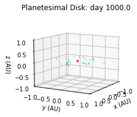

```python
FFMpegWriter = ani.writers['ffmpeg']                            #make 3D animation to display dataset
writer = FFMpegWriter(fps=20)

fig = plt.figure(figsize=(4,3))              #set up 3D figure
fig.patch.set_alpha(1.0)
ax = plt.axes(projection='3d')

with writer.saving(fig, "planetesimal_disk_3D.mp4", 200):
    for i in range(0,len(times_pDisk),10):                 #one frame per day
        plt.cla()
        ax.view_init(10, 30)

        ax.scatter(position_history_pDisk[:,0,i]/AU,position_history_pDisk[:,1,i]/AU,
                   position_history_pDisk[:,2,i]/AU,s=normal_masses_pDisk,color=colorlist)
        ax.set_xlim(-1,1); ax.set_ylim(-1,1); ax.set_zlim(-1,1)
        ax.set_xlabel('x (AU)'); ax.set_ylabel('y (AU)'); ax.set_zlabel('z (AU)')
        ax.set_title(f'Planetesimal Disk: day {times_pDisk[i]/86400}')

        if i % 500 == 0:
            print(f"saving movie frame {i}")
        writer.grab_frame()
```

```python
from IPython.display import Video
Video("planetesimal_disk_3D.mp4", embed=True)
```

[video not shown]

```
saving movie frame 0
saving movie frame 500
saving movie frame 1000
saving movie frame 1500
saving movie frame 2000
saving movie frame 2500
saving movie frame 3000
saving movie frame 3500
saving movie frame 4000
saving movie frame 4500
saving movie frame 5000
saving movie frame 5500
saving movie frame 6000
saving movie frame 6500
saving movie frame 7000
saving movie frame 7500
saving movie frame 8000
saving movie frame 8500
saving movie frame 9000
saving movie frame 9500
saving movie frame 10000
```

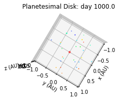

```python
FFMpegWriter = ani.writers['ffmpeg']                            #redo animation from top-down view
writer = FFMpegWriter(fps=20)

fig = plt.figure(figsize=(4,3))              #set up 3D figure
fig.patch.set_alpha(1.0)
ax = plt.axes(projection='3d')

with writer.saving(fig, "planetesimal_disk_3D_topdown.mp4", 200):
    for i in range(0,len(times_pDisk),10):                 #one frame per day
        plt.cla()
        ax.view_init(90, 30)

        ax.scatter(position_history_pDisk[:,0,i]/AU,position_history_pDisk[:,1,i]/AU,
                   position_history_pDisk[:,2,i]/AU,s=normal_masses_pDisk,color=colorlist)
        ax.set_xlim(-1,1); ax.set_ylim(-1,1); ax.set_zlim(-1,1)
        ax.set_xlabel('x (AU)'); ax.set_ylabel('y (AU)'); ax.set_zlabel('z (AU)')
        ax.set_title(f'Planetesimal Disk: day {times_pDisk[i]/86400}')

        if i % 500 == 0:
            print(f"saving movie frame {i}")
        writer.grab_frame()
```

```python
from IPython.display import Video
Video("planetesimal_disk_3D_topdown.mp4", embed=True)
```

[video not shown]

I was hoping to see the planetesimals interact more, changing one another's orbits, perhaps even ejecting one of the planetesimals from the system. It could be that my time steps are too large to demonstrate this behavior, or it could just be that my total time is too short.  
However, running 30 objects for 1000 days at 0.1 day time steps already imposed significant computational burden. It took around 10 minutes just to run the cell which computes the trajectories. Since I had no direct evidence that anything was amiss with the results, I decided these videos were adequate.